# 1. Sinusoidal Steady-State Analysis

## 3.2. Bode Plots: Angle

1) Asymptotic Behavior: Isolated zero

$$ H(s) = s - z_1$$

- The angle response is simple at low and high frequencies

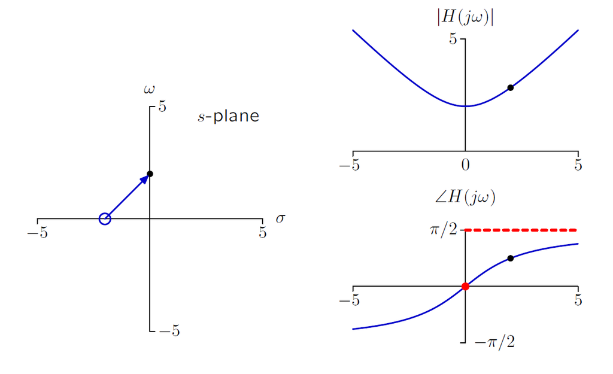

- Three straight lines provide a good approximation versus $\log \omega$

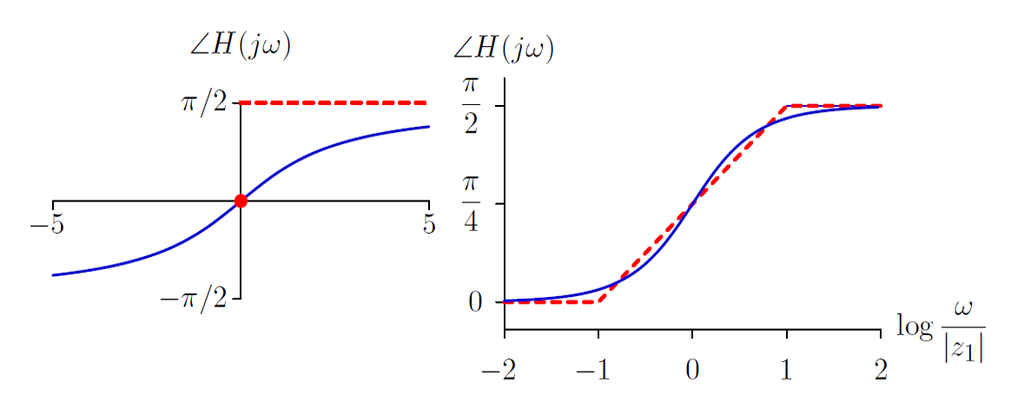

$$ \begin{align*} \lim_{\omega \rightarrow 0} \angle H(j \omega ) &= 0 \\\\ \lim_{\omega \rightarrow \infty} \angle H(j \omega ) &= \frac{\pi}{2} \end{align*} $$

2) Asymptotic Behavior: Isolated Pole

$$ H(s) = \frac{9}{s - p_1}$$

- The angle response is simple at low and high frequencies

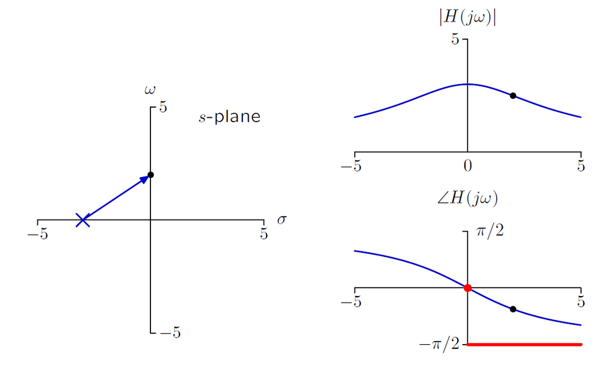

- Three straight lines provide a good approximation versus $\log \omega$

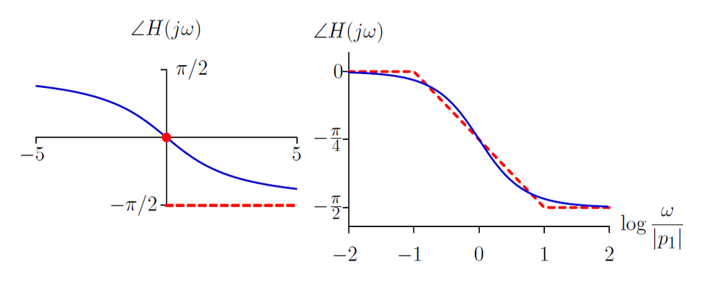

$$ \begin{align*} \lim_{\omega \rightarrow 0} \angle H(j \omega ) &= 0 \\\\ \lim_{\omega \rightarrow \infty} \angle H(j \omega ) &= -\frac{\pi}{2} \end{align*} $$

3) Asymptotic Behavior of More Complicated Systems

$$H(s_0) = K \frac{\prod_{m=1}^{M}(s_0 - z_m)}{\prod_{n=1}^{N}(s_0 - p_n)}$$

- The angle of a product is the sum of the angles

$$ \angle H(s_0) = \angle K + \sum_{m=1}^{M} \angle (s_0 - z_m) - \sum_{n=1}^{N} \angle (s_0 - p_n) $$

$$ \angle H(j \omega) = \angle K + \sum_{m=1}^{M} \angle (j \omega - z_m) - \sum_{n=1}^{N} \angle (j \omega - p_n) $$

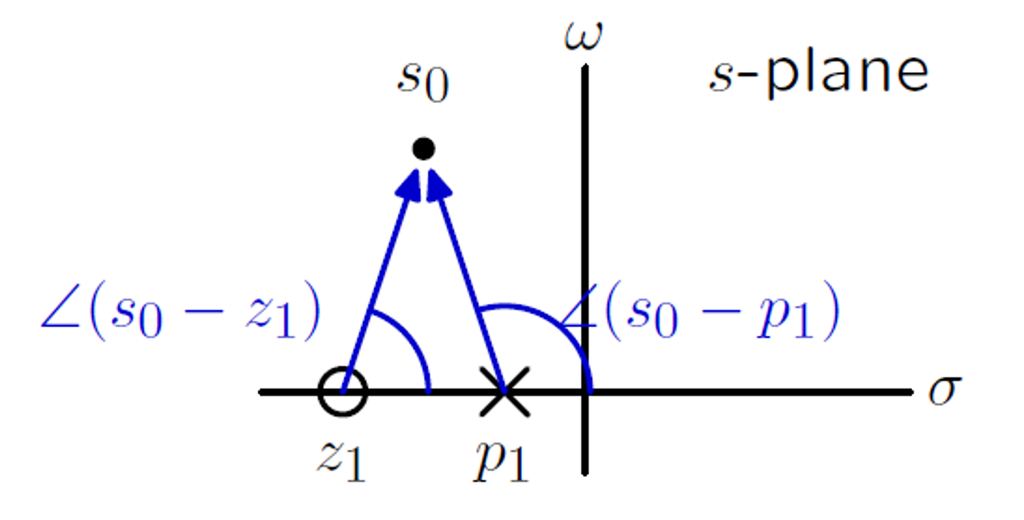

- The angle of $K$ can be $0$ or $\pi$ for systems described by linear differential equations with constant, real-value coefficients

$$H(s) = \frac{s}{(s+1)(s+10)}$$

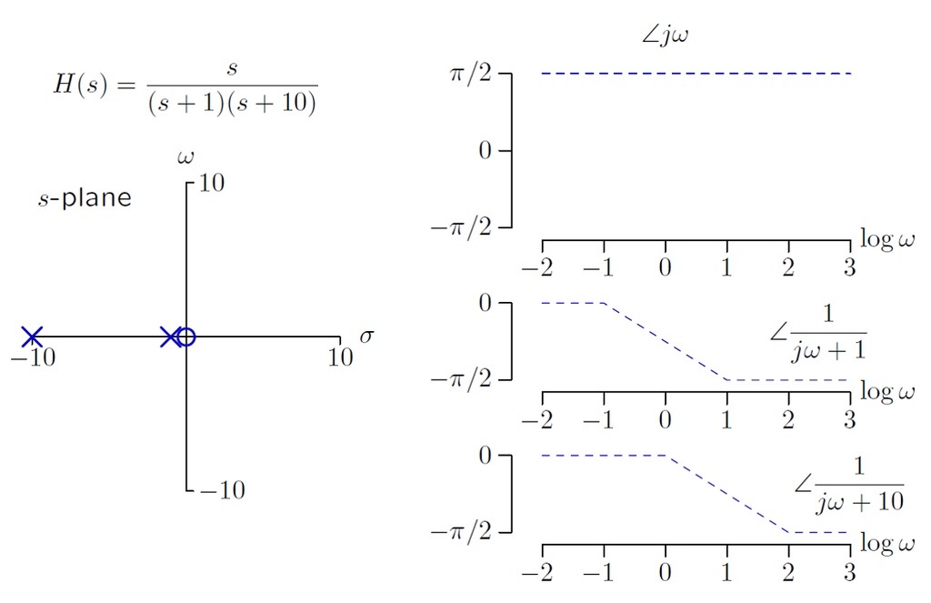

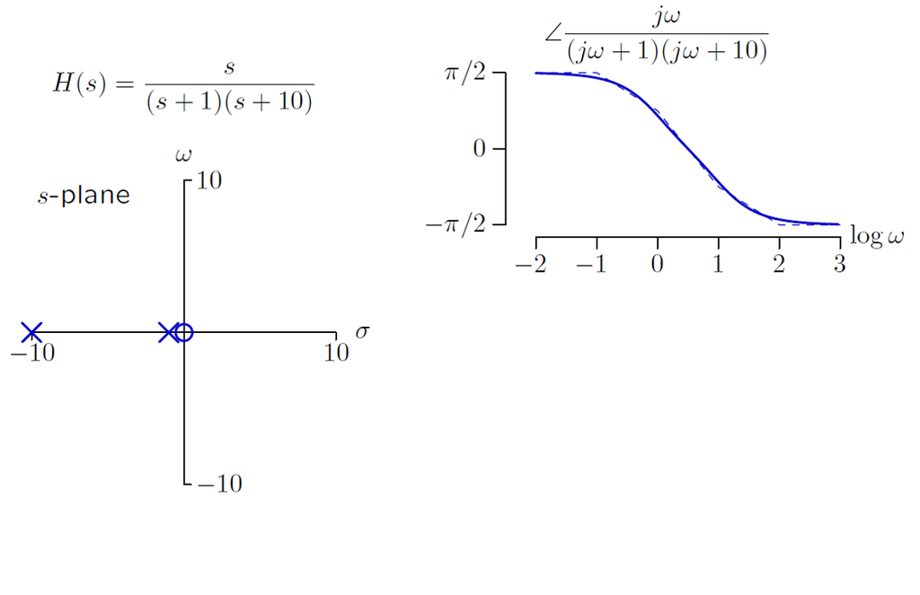

## 3.3. Bode Plot in dB

- Bode plot (logarithmic plot) : separate plots for magnitude and phase

$$20 \log_{10} \lvert H(j\omega) \rvert$$

- Example

$$H(s) = \frac{10s}{(s+1)(s+10)}$$

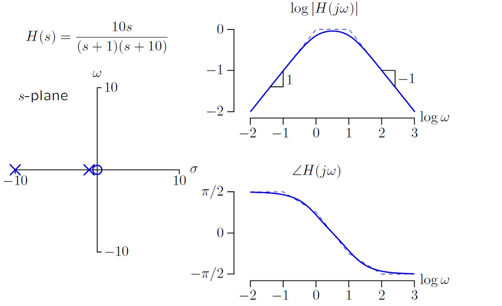

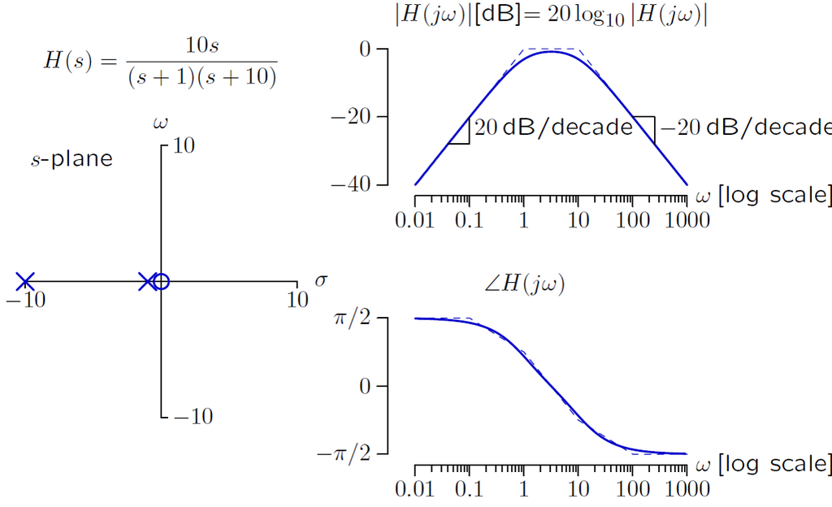

```matlab
%%html
<center><iframe src="https://www.youtube.com/embed/_eh1conN6YM?rel=0"
width="560" height="315" frameborder="0" allowfullscreen></iframe></center>
```

[video not shown]

```matlab
%%html
<center><iframe src="https://www.youtube.com/embed/CSAp9ooQRT0?rel=0"
width="560" height="315" frameborder="0" allowfullscreen></iframe></center>
```

[video not shown]

```matlab
%%html
<center><iframe src="https://www.youtube.com/embed/E6R2XUEyRy0?rel=0"
width="560" height="315" frameborder="0" allowfullscreen></iframe></center>
```

[video not shown]

```matlab
%%html
<center><iframe src="https://www.youtube.com/embed/O2Cw_4zd-aU?rel=0"
width="560" height="315" frameborder="0" allowfullscreen></iframe></center>
```

[video not shown]

```matlab
%%html
<center><iframe src="https://www.youtube.com/embed/4d4WJdU61Js?rel=0"
width="560" height="315" frameborder="0" allowfullscreen></iframe></center>
```

[video not shown]

```matlab
%%html
<center><iframe src="https://www.youtube.com/embed/GIlx9Yu__y8?rel=0"
width="560" height="315" frameborder="0" allowfullscreen></iframe></center>
```

[video not shown]

# 4. Frequency Response and Nyquist Plots

- If we only want a single plot we can use $\omega$ as a parameter
- A plot of $Re\{G(\omega)\}$ vs. $Im\{G(\omega)\}$ as a function of $\omega$
  - Advantage: all information in a single plot

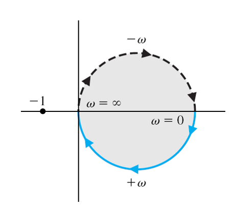

$$G(s) = \frac{1}{s+1}$$

```matlab
G = tf([1],[1,1]);
```

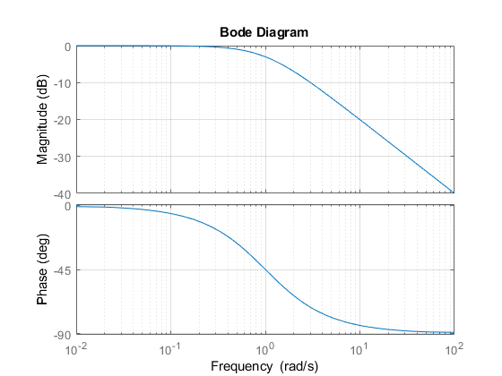

```matlab
bode(G)
grid on
```

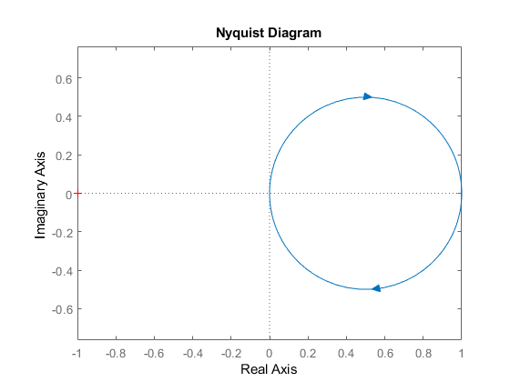

```matlab
nyquist(G)
axis equal
```

$$G(s) = \frac{1}{(s+1)(0.1s + 1)}$$

```matlab
G = tf([1],conv([1,1],[0.1,1]));
```

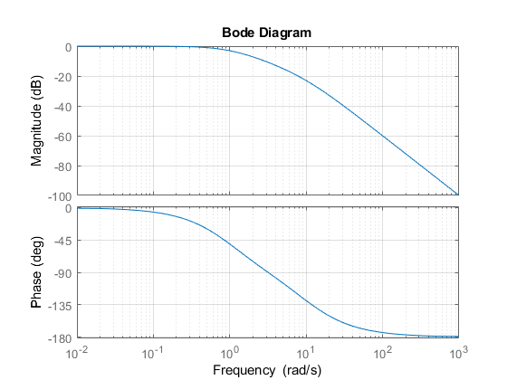

```matlab
bode(G)
grid on
```

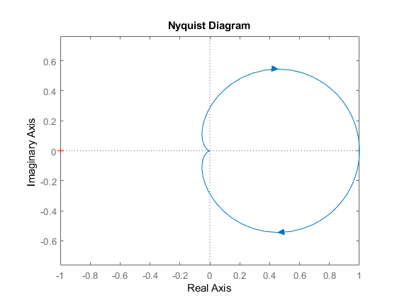

```matlab
nyquist(G)
axis equal
```

$$G(s) = \frac{1}{(s+1)^3}$$

```matlab
s = tf('s');
G = 1/(s+1)^3;
```

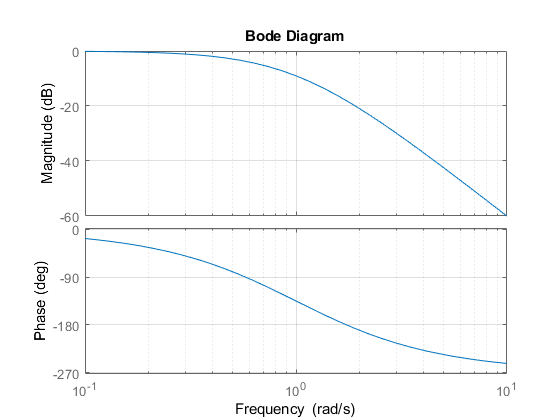

```matlab
bode(G)
grid on
```

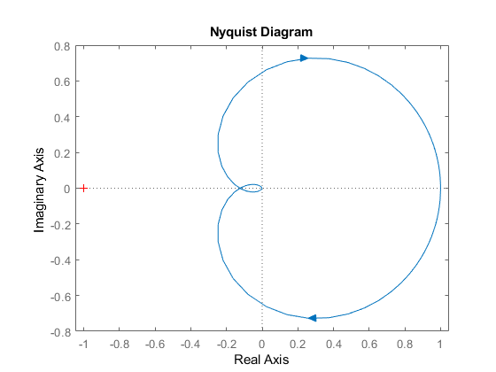

```matlab
nyquist(G)
axis equal
```

```matlab
%%javascript
$.getScript('https://kmahelona.github.io/ipython_notebook_goodies/ipython_notebook_toc.js')
```